# Series de tiempo: Tarea 1

Guillermo Alberto Garcia Candanosa - A01034958

2022-04-25

Librerías requeridas para instalar:

```r
install.packages("tidyverse")
install.packages("fpp3")
install.packages("forecast")
install.packages("ggplot2")
install.packages("astsa")
install.packages("GGally")
install.packages("fma")
install.packages("expsmooth")
install.packages("tsibble")
```

Carga de librerías:

```r
library("tidyverse")
library("fpp3")
library("forecast")
library("ggplot2")
library("astsa")
library("GGally")
library("fma")
library("expsmooth")
library("tsibble")
```

1. Una serie de tiempo es una secuencia de observaciones (o números) sobre intervalos de tiempo separados de manera regular (el índice). En R, esta información se puede almacenar en un formato llamado “tsibble”, el cual nos permite graficar la información.
1. Convierte la serie de tiempo de la siguiente tabla en “tsibble” en R.

```r
y <- tsibble(
Year = 2015:2019,
Observation = c(48, 36, 25, 30, 68),
index = Year
)
```

2. Grafica la serie. Puedes usar el siguiente código:

```
Plot variable not specified, automatically selected `.vars = Observation`
```

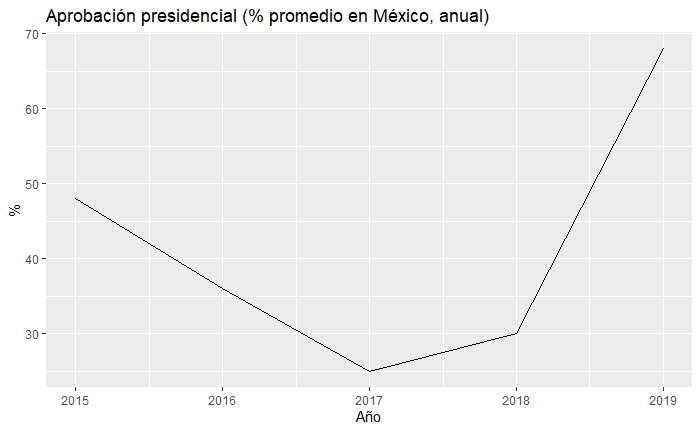

```r
autoplot(y) +
  ggtitle("Aprobación presidencial (% promedio en México, anual)") +
  ylab("%") +
  xlab("Año")
```

3. ¿La serie sigue alguna tendencia, estacionalidad o ciclo?

2. Carga la base de datos “tute1.csv”, que puedes ubicar en el sitio del curso en Canvas. Tiene 4 columnas: Quarter, Sales (ventas trimestrales de una tienda de teléfonos), AdBudget (es el presupuesto para publicidad de la tienda (en dólares australianos) y GDP (Producto interno bruto de Australia, en dólares australianos). La serie ya fue ajustada por inflación.
1. Carga la base de datos en R (recuerda asignar un directorio de trabajo y ahí guardar la base de datos (ejemplo: setwd(“E:TS”).

```r
tute1 <- read_csv("tute1.csv")
```

2. Transforma los datos en una serie de tiempo para R.

```r
mytimeseries <- tute1 %>%
  mutate(Quarter = yearmonth(Quarter)) %>%
  as_tsibble(index = Quarter)
```

3. Grafica las series de tiempo de las variables en la base de datos.

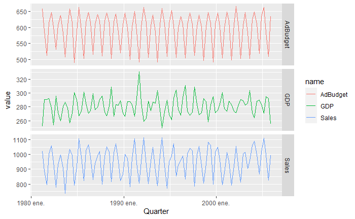

```r
mytimeseries %>%
  pivot_longer(-Quarter) %>%
  ggplot(aes(x = Quarter, y = value, colour = name)) +
  geom_line() +
  facet_grid(name ~ ., scales = "free_y")
```

4. Revisa qué pasa cuando no incluyes facet_grid().

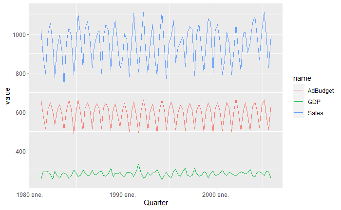

```r
mytimeseries %>%
  pivot_longer(-Quarter) %>%
  ggplot(aes(x = Quarter, y = value, colour = name)) +
  geom_line()
```

*R: Al no incluir facet_grid(), las tres series de tiempo se grafican en una misma gráfica. El facet_grid() permite graficar cada serie de tiempo por separado dentro de un mismo output, lo cual permite visualizar el comportamiento de los datos de forma independiente en escalas distintas según el caso.*